# 04 - Size-selective fishing and the restructuring of population demography

Results 2.2: gear selectivity, length-at-age, age-structure change points (Supplementary Fig. S3)

Sarah Ohayon, Jacob T. Dingwall, Amanda E. Bates

2026-10-01

```r
bio_src   <- read_csv(file.path(DERIVED, "biosample_annual_by_source.csv"), show_col_types = FALSE)
test_age  <- read_csv(file.path(DERIVED, "test_fishery_age.csv"),           show_col_types = FALSE)
len_age   <- read_csv(file.path(DERIVED, "length_at_age.csv"),              show_col_types = FALSE)
catchdec  <- read_csv(file.path(DERIVED, "catch_decomposition.csv"),        show_col_types = FALSE)
```

## 1 The fishery transition: season, gear and demographic target

```r
catchdec %>%
  filter(area %in% BIO_AREAS, fishery %in% c("Reduction","Roe","Food and bait")) %>%
  group_by(fishery, gear_grp) %>%
  summarise(catch_kt = round(sum(catch_t, na.rm = TRUE)/1000), .groups = "drop") %>%
  pivot_wider(names_from = gear_grp, values_from = catch_kt, values_fill = 0) %>%
  kable(caption = "Total catch (kt) by fishery type and gear, statistical areas 13-18")
```

Total catch (kt) by fishery type and gear, statistical areas 13-18

| fishery | Gillnet | Other | Seine | Trawl |
| --- | --- | --- | --- | --- |
| Food and bait | 1 | 0 | 121 | 8 |
| Reduction | 0 | 582 | 834 | 5 |
| Roe | 321 | 0 | 229 | 0 |

```r
roe <- catchdec %>% filter(area %in% BIO_AREAS, fishery == "Roe",
                           gear_grp %in% c("Seine","Gillnet"), Year %in% 1972:2025)
gn_share_overall <- with(roe, sum(catch_t[gear_grp == "Gillnet"], na.rm = TRUE) /
                              sum(catch_t, na.rm = TRUE))
gn_annual <- roe %>% group_by(Year, gear_grp) %>%
  summarise(c = sum(catch_t, na.rm = TRUE), .groups = "drop") %>%
  group_by(Year) %>% summarise(share = c[gear_grp == "Gillnet"]/sum(c), .groups = "drop")

cat(sprintf("Gillnets took %.0f%% of the roe catch 1972-2025; annual share IQR %.0f-%.0f%%\n",
            100*gn_share_overall,
            100*quantile(gn_annual$share, .25, na.rm = TRUE),
            100*quantile(gn_annual$share, .75, na.rm = TRUE)))
```

```
## Gillnets took 58% of the roe catch 1972-2025; annual share IQR 49-73%
```

## 2 Age composition differs among sampling sources (Fig. 2b)

The question is whether the sources are sampling the same age structure or different ones. Each row of the data is one source-year, with counts of old (age ≥ 5) and young fish.

**Why not a plain binomial model.** A binomial model assumes every fish is an independent draw, so its variance is fixed by the counts. Fish are caught in schools and sampled in sets, so the real year-to-year scatter is far larger: residual deviance/df is ~100, i.e. the data are ~100× overdispersed. Under that assumption the standard errors are ~10× too small and AIC differences become meaningless. Two corrections are used instead:

1. **Quasibinomial GAM** - the same model, but the dispersion is estimated from the data rather than fixed at 1, and the common-trend vs source-specific-trend comparison is an F test.
2. **Binomial GAM with an observation-level random effect** (`s(obs, bs = "re")`) - each source-year gets its own random deviation, which absorbs the extra scatter. With one shared temporal smooth, the source coefficients are the difference in *level* between sources, reported as odds ratios relative to the test fishery (the closest index of the spawning population). AIC is not used with this model: the observation-level effect absorbs source differences, so conditional AIC is unreliable for comparing fixed effects; Wald tests are used.

Caveat: reduction samples (1946-1972) do not overlap in time with the test fishery (1975-), so that contrast relies on the shared temporal smooth.

```r
gd <- bio_src %>%
  mutate(src = factor(src, levels = c("Reduction","Roe seine","Roe gillnet",
                                      "Food and bait","Test fishery"))) %>%
  filter(!is.na(src)) %>%
  mutate(obs = factor(row_number()))

## plain binomial, kept only to document the overdispersion
m_source_bin <- gam(cbind(n_old, n_young) ~ src + s(Year, by = src, k = 8),
                    family = binomial, data = gd, method = "REML")
cat(sprintf("Source-years: %d | fish: %s | binomial residual deviance/df = %.1f (1 = no overdispersion)\n",
            nrow(gd), format(sum(gd$n_fish), big.mark = ","),
            deviance(m_source_bin) / df.residual(m_source_bin)))
```

```
## Source-years: 227 | fish: 563,327 | binomial residual deviance/df = 96.7 (1 = no overdispersion)
```

```r
## 1  quasibinomial: common trend vs source-specific trends
## trends are regression splines with a fixed 7 df (k = 8, fx = TRUE), the model drawn in Fig. 2b:
## with automatic smoothing the ~100x overdispersion flattens every source trend
m_common <- gam(cbind(n_old, n_young) ~ s(Year, k = 8, fx = TRUE),
                family = quasibinomial, data = gd)
m_source <- gam(cbind(n_old, n_young) ~ src + s(Year, by = src, k = 8, fx = TRUE),
                family = quasibinomial, data = gd)
f_src <- anova(m_common, m_source, test = "F")
cat(sprintf("Quasibinomial: dispersion = %.1f | source-specific vs common trend F = %.1f, P %s\n",
            summary(m_source)$scale, f_src$F[2], fmt_p(f_src$`Pr(>F)`[2])))
```

```
## Quasibinomial: dispersion = 96.8 | source-specific vs common trend F = 21.0, P < 0.001
```

```r
cat(sprintf("Deviance explained: common %.1f%%, source-specific %.1f%%\n",
            100*summary(m_common)$dev.expl, 100*summary(m_source)$dev.expl))
```

```
## Deviance explained: common 19.2%, source-specific 82.3%
```

```r
## 2  shared trend + source levels + observation-level random effect: odds ratios vs test fishery
gd_or <- gd %>% mutate(src = relevel(src, ref = "Test fishery"))
m_level <- gam(cbind(n_old, n_young) ~ src + s(Year, k = 8) + s(obs, bs = "re"),
               family = binomial, data = gd_or, method = "REML")
pt <- summary(m_level)$p.table[-1, , drop = FALSE]
src_or <- tibble(Source = sub("^src", "", rownames(pt)),
                 `OR vs test fishery` = exp(pt[, 1]),
                 lower = exp(pt[, 1] - 1.96 * pt[, 2]),
                 upper = exp(pt[, 1] + 1.96 * pt[, 2]),
                 P = pt[, 4])
save_tab(src_or, "prop_old_source_odds_ratios")
kable(src_or, digits = c(0, 2, 2, 2, 4),
      caption = "Odds of an old fish (age >= 5) relative to the test fishery (shared trend, observation-level random effect)")
```

Odds of an old fish (age >= 5) relative to the test fishery (shared trend, observation-level random effect)

| Source | OR vs test fishery | lower | upper | P |
| --- | --- | --- | --- | --- |
| Reduction | 0.39 | 0.26 | 0.57 | 0.0000 |
| Roe seine | 1.47 | 1.16 | 1.86 | 0.0014 |
| Roe gillnet | 9.92 | 7.86 | 12.53 | 0.0000 |
| Food and bait | 0.78 | 0.62 | 0.98 | 0.0322 |

```r
src_summary <- gd %>% group_by(src) %>%
  summarise(years   = paste(range(Year), collapse = "-"),
            n_years = n(),
            prop_old_count  = sprintf("%.2f +/- %.2f", mean(prop_old_n), sd(prop_old_n)),
            prop_old_weight = sprintf("%.2f +/- %.2f", mean(prop_old_wt, na.rm = TRUE),
                                      sd(prop_old_wt, na.rm = TRUE)),
            .groups = "drop")
save_tab(src_summary, "prop_old_by_sampling_source")
kable(src_summary,
      caption = "Proportion of old fish (age >= 5) by sampling source, mean +/- SD across years")
```

Proportion of old fish (age >= 5) by sampling source, mean +/- SD across years

| src | years | n_years | prop_old_count | prop_old_weight |
| --- | --- | --- | --- | --- |
| Reduction | 1946-1972 | 21 | 0.11 +/- 0.07 | 0.15 +/- 0.09 |
| Roe seine | 1972-2024 | 49 | 0.29 +/- 0.10 | 0.36 +/- 0.11 |
| Roe gillnet | 1972-2024 | 52 | 0.71 +/- 0.13 | 0.73 +/- 0.13 |
| Food and bait | 1950-2024 | 57 | 0.19 +/- 0.11 | 0.25 +/- 0.12 |
| Test fishery | 1977-2024 | 48 | 0.22 +/- 0.08 | 0.29 +/- 0.09 |

```r
## the roe-gillnet trajectory quoted in the Results
rg <- gd %>% filter(src == "Roe gillnet") %>% arrange(Year)
cat(sprintf("Roe gillnet: %.2f in %d rising to %.2f by %d; mean over 1980-2024 = %.2f +/- %.2f\n",
            rg$prop_old_n[1], rg$Year[1],
            max(rg$prop_old_n[rg$Year <= 1980]), rg$Year[which.max(replace(rg$prop_old_n, rg$Year > 1980, NA))],
            mean(rg$prop_old_n[rg$Year >= 1980]), sd(rg$prop_old_n[rg$Year >= 1980])))
```

```
## Roe gillnet: 0.38 in 1972 rising to 0.89 by 1980; mean over 1980-2024 = 0.73 +/- 0.12
```

```r
## fold-change in selectivity, by weight
red_wt <- gd %>% filter(src == "Reduction")   %>% pull(prop_old_wt)
gil_wt <- gd %>% filter(src == "Roe gillnet") %>% pull(prop_old_wt)
cat(sprintf("By weight: reduction %.2f +/- %.2f -> roe gillnet %.2f +/- %.2f (%.1f-fold)\n",
            mean(red_wt, na.rm = TRUE), sd(red_wt, na.rm = TRUE),
            mean(gil_wt, na.rm = TRUE), sd(gil_wt, na.rm = TRUE),
            mean(gil_wt, na.rm = TRUE)/mean(red_wt, na.rm = TRUE)))
```

```
## By weight: reduction 0.15 +/- 0.09 -> roe gillnet 0.73 +/- 0.13 (4.8-fold)
```

## 3 Length-at-age (Fig. 2c)

```r
la <- len_age %>% mutate(age_f = factor(age))
m_len_common <- gam(mean_len_mm ~ age_f + s(Year, k = 8), weights = n,
                    data = la, method = "REML")
m_len_byage  <- gam(mean_len_mm ~ age_f + s(Year, by = age_f, k = 8), weights = n,
                    data = la, method = "REML")
cat(sprintf("Length-at-age: common smooth AIC = %.0f, age-specific smooths AIC = %.0f (dAIC = %.0f)\n",
            AIC(m_len_common), AIC(m_len_byage), AIC(m_len_common) - AIC(m_len_byage)))
```

```
## Length-at-age: common smooth AIC = 2457, age-specific smooths AIC = 2337 (dAIC = 121)
```

```r
## change in mean length-at-age between eras, per age class
la %>% mutate(era = case_when(Year <= 1979 ~ "<=1979",
                              Year <= 1983 ~ "1980-1983",
                              TRUE         ~ ">=1984")) %>%
  group_by(age, era) %>%
  summarise(mean_cm = round(weighted.mean(mean_len_mm, n)/10, 1), .groups = "drop") %>%
  pivot_wider(names_from = era, values_from = mean_cm) %>%
  mutate(`change 1980-83 vs <=1979 (cm)` = `1980-1983` - `<=1979`,
         `change >=1984 vs <=1979 (cm)`  = `>=1984`   - `<=1979`) %>%
  kable(caption = "Mean length-at-age (cm) by age class and era, sample-size weighted")
```

Mean length-at-age (cm) by age class and era, sample-size weighted

| age | 1980-1983 | <=1979 | >=1984 | change 1980-83 vs <=1979 (cm) | change >=1984 vs <=1979 (cm) |
| --- | --- | --- | --- | --- | --- |
| 2 | 16.2 | 15.3 | 15.8 | 0.9 | 0.5 |
| 3 | 18.2 | 18.5 | 17.7 | -0.3 | -0.8 |
| 4 | 19.6 | 19.8 | 18.8 | -0.2 | -1.0 |
| 5 | 20.6 | 20.9 | 19.7 | -0.3 | -1.2 |
| 6 | 21.4 | 21.8 | 20.5 | -0.4 | -1.3 |
| 7 | 22.0 | 22.5 | 21.1 | -0.5 | -1.4 |
| 8 | 22.4 | 22.6 | 22.1 | -0.2 | -0.5 |
| 9 | 22.7 | NA | NA | NA | NA |

## 4 Test-fishery age structure: the three-phase contrast

The test fishery began in 1975 and samples during the spawning season, and so is the closest available fishery-independent index of the spring spawning population. Mean age and the proportion of old fish are contrasted across three phases: pre-collapse (≤ 1983), the collapse itself (1984-1986) and the post-collapse period (≥ 1987).

A one-way ANOVA is used rather than a change-point test because the trajectory is a drop **and a partial recovery**, which a single-breakpoint model cannot represent; on mean age the change-point test returns a false negative for exactly that reason (Section 5).

```r
ta <- test_age %>% mutate(phase = factor(PHASE3(Year),
                                         levels = c("Pre-collapse","Collapse","Post-collapse")))

phase_test <- function(var, label) {
  f  <- as.formula(paste(var, "~ phase"))
  a  <- aov(f, data = ta); s <- summary(a)[[1]]
  mu <- ta %>% group_by(phase) %>%
    summarise(m = mean(.data[[var]]), sd = sd(.data[[var]]), n = n(), .groups = "drop")
  cat(sprintf("\n== %s ==\n", label))
  for (i in seq_len(nrow(mu)))
    cat(sprintf("  %-14s %.2f +/- %.2f (n = %d years)\n",
                mu$phase[i], mu$m[i], mu$sd[i], mu$n[i]))
  cat(sprintf("  ANOVA: F(%d,%d) = %.2f, P %s\n",
              s$Df[1], s$Df[2], s$`F value`[1], fmt_p(s$`Pr(>F)`[1])))
  tibble(Metric = label,
         `Pre-collapse`  = sprintf("%.2f +/- %.2f", mu$m[1], mu$sd[1]),
         `Collapse (1984-1986)` = sprintf("%.2f +/- %.2f", mu$m[2], mu$sd[2]),
         `Post-collapse` = sprintf("%.2f +/- %.2f", mu$m[3], mu$sd[3]),
         df = sprintf("%d, %d", s$Df[1], s$Df[2]),
         F  = round(s$`F value`[1], 2),
         P  = signif(s$`Pr(>F)`[1], 3))
}

three_phase <- bind_rows(
  phase_test("mean_age",  "Mean age (years)"),
  phase_test("prop_age5", "Proportion age >= 5"),
  phase_test("prop_age4", "Proportion age >= 4"),
  phase_test("prop_juv",  "Proportion age 1-3"))
```

```
##
## == Mean age (years) ==
##   Pre-collapse   4.06 +/- 0.25 (n = 7 years)
##   Collapse       3.38 +/- 0.30 (n = 3 years)
##   Post-collapse  3.69 +/- 0.20 (n = 38 years)
##   ANOVA: F(2,45) = 13.44, P < 0.001
##
## == Proportion age >= 5 ==
##   Pre-collapse   0.30 +/- 0.09 (n = 7 years)
##   Collapse       0.14 +/- 0.07 (n = 3 years)
##   Post-collapse  0.21 +/- 0.06 (n = 38 years)
##   ANOVA: F(2,45) = 7.93, P = 0.001
##
## == Proportion age >= 4 ==
##   Pre-collapse   0.58 +/- 0.12 (n = 7 years)
##   Collapse       0.35 +/- 0.10 (n = 3 years)
##   Post-collapse  0.50 +/- 0.13 (n = 38 years)
##   ANOVA: F(2,45) = 3.61, P = 0.035
##
## == Proportion age 1-3 ==
##   Pre-collapse   0.42 +/- 0.12 (n = 7 years)
##   Collapse       0.65 +/- 0.10 (n = 3 years)
##   Post-collapse  0.50 +/- 0.13 (n = 38 years)
##   ANOVA: F(2,45) = 3.61, P = 0.035
```

```r
save_tab(three_phase, "test_fishery_three_phase_contrasts")
kable(three_phase, caption = "Test-fishery age structure across the three phases (one-way ANOVA)")
```

Test-fishery age structure across the three phases (one-way ANOVA)

| Metric | Pre-collapse | Collapse (1984-1986) | Post-collapse | df | F | P |
| --- | --- | --- | --- | --- | --- | --- |
| Mean age (years) | 4.06 +/- 0.25 | 3.38 +/- 0.30 | 3.69 +/- 0.20 | 2, 45 | 13.44 | 2.65e-05 |
| Proportion age >= 5 | 0.30 +/- 0.09 | 0.14 +/- 0.07 | 0.21 +/- 0.06 | 2, 45 | 7.93 | 1.12e-03 |
| Proportion age >= 4 | 0.58 +/- 0.12 | 0.35 +/- 0.10 | 0.50 +/- 0.13 | 2, 45 | 3.61 | 3.53e-02 |
| Proportion age 1-3 | 0.42 +/- 0.12 | 0.65 +/- 0.10 | 0.50 +/- 0.13 | 2, 45 | 3.61 | 3.53e-02 |

```r
cat(sprintf("\nTest-fishery series: %d years, %d-%d\n",
            nrow(ta), min(ta$Year), max(ta$Year)))
```

```
##
## Test-fishery series: 48 years, 1977-2024
```

## 5 Change-point analysis of age structure (Supplementary Fig. S3)

Piecewise regression with a single breakpoint estimated from a 1986 starting value; the Davies test asks whether a change in slope is present at all. Proportions are fitted as binomial models weighted by the number of aged fish.

```r
wt_age <- ta$n_fish

fit_cp <- function(model, label) {
  seg <- try(segmented(model, seg.Z = ~Year, psi = list(Year = 1986)), silent = TRUE)
  if (inherits(seg, "try-error")) return(NULL)
  ps <- summary(seg)$psi
  dv <- tryCatch(davies.test(model, ~Year), error = function(e) NULL)
  list(seg = seg,
       row = tibble(Metric = label,
                    `Break year` = round(ps[, "Est."], 1),
                    SE           = round(ps[, "St.Err"], 2),
                    `95% CI`     = sprintf("%.1f-%.1f",
                                           ps[,"Est."] - 1.96*ps[,"St.Err"],
                                           ps[,"Est."] + 1.96*ps[,"St.Err"]),
                    `Davies P`   = if (is.null(dv)) NA_real_ else signif(dv$p.value, 3)),
       fitted = if (inherits(model, "glm") && family(model)$family == "binomial")
                  fitted(seg, type = "response") else fitted(seg))
}

m_mean  <- lm(mean_age ~ Year, data = ta)
m_a6    <- glm(prop_age6 ~ Year, family = binomial, data = ta, weights = wt_age)
m_a5    <- glm(prop_age5 ~ Year, family = binomial, data = ta, weights = wt_age)
m_a4    <- glm(prop_age4 ~ Year, family = binomial, data = ta, weights = wt_age)
m_juv   <- glm(prop_juv  ~ Year, family = binomial, data = ta, weights = wt_age)
m_a3    <- glm(prop_age3 ~ Year, family = binomial, data = ta, weights = wt_age)
m_a12   <- glm(prop_age12 ~ Year, family = binomial, data = ta, weights = wt_age)

cps <- list(
  `Mean age`            = fit_cp(m_mean, "Mean age (years)"),
  `Proportion age >= 6` = fit_cp(m_a6,   "Proportion age >= 6"),
  `Proportion age >= 5` = fit_cp(m_a5,   "Proportion age >= 5"),
  `Proportion age >= 4` = fit_cp(m_a4,   "Proportion age >= 4"),
  `Proportion age 1-3`  = fit_cp(m_juv,  "Proportion age 1-3"),
  `Proportion age 3`    = fit_cp(m_a3,   "Proportion age 3"),
  `Proportion age 1-2`  = fit_cp(m_a12,  "Proportion age 1-2"))

cp_tab <- map_dfr(cps, "row")
save_tab(cp_tab, "age_structure_changepoints")
kable(cp_tab, caption = "Change-point analysis of test-fishery age structure (segmented regression, Davies test)")
```

Change-point analysis of test-fishery age structure (segmented regression, Davies test)

| Metric | Break year | SE | 95% CI | Davies P |
| --- | --- | --- | --- | --- |
| Mean age (years) | 1985.0 | 2.92 | 1979.3-1990.7 | 0.28 |
| Proportion age >= 6 | 1986.0 | 0.33 | 1985.3-1986.7 | 0.00 |
| Proportion age >= 5 | 1985.1 | 0.22 | 1984.7-1985.6 | 0.00 |
| Proportion age >= 4 | 1985.0 | 0.21 | 1984.6-1985.4 | 0.00 |
| Proportion age 1-3 | 1985.0 | 0.21 | 1984.6-1985.4 | 0.00 |
| Proportion age 3 | 1986.0 | 0.62 | 1984.8-1987.2 | 0.00 |
| Proportion age 1-2 | 1985.0 | 0.16 | 1984.7-1985.3 | 0.00 |

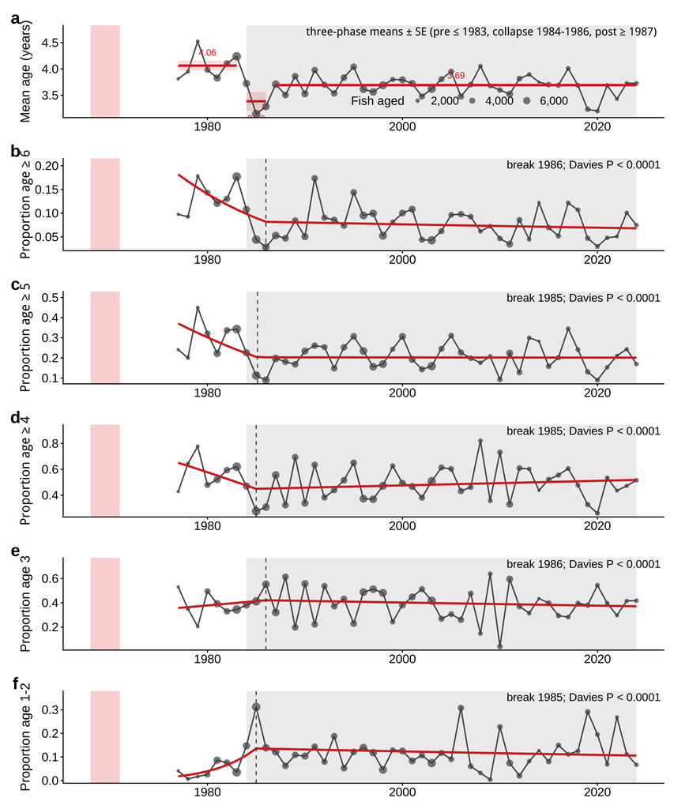

```r
## Fig. S3 panels: age 1-3 (still in the change-point table) is split into age 3 (e) and
## age 1-2 (f) in the figure
fig_cps <- cps[c("Mean age", "Proportion age >= 6", "Proportion age >= 5",
                 "Proportion age >= 4", "Proportion age 3", "Proportion age 1-2")]
yvars <- c("mean_age","prop_age6","prop_age5","prop_age4","prop_age3","prop_age12")
ylabs <- c("Mean age (years)","Proportion age ≥ 6","Proportion age ≥ 5",
           "Proportion age ≥ 4","Proportion age 3","Proportion age 1-2")

## Panel a (mean age) shows the three-phase contrast reported in the Results, not a change
## point: mean age falls and then partially recovers, so a single break describes it poorly
## and the Davies test does not reject. The other panels keep the change-point fits.
PHASE_PANELS <- "mean_age"
phase_means <- function(v) ta %>%
  mutate(ph = factor(PHASE3(Year), levels = c("Pre-collapse","Collapse","Post-collapse"))) %>%
  group_by(ph) %>%
  summarise(m = mean(.data[[v]]), se = sd(.data[[v]])/sqrt(n()),
            x0 = min(Year), x1 = max(Year), .groups = "drop")

panels <- map(seq_along(fig_cps), function(i) {
  cp <- fig_cps[[i]]; v <- yvars[i]
  bp <- as.numeric(summary(cp$seg)$psi[, "Est."])
  dv <- cp$row$`Davies P`
  p <- ggplot(ta, aes(Year, .data[[v]])) +
    band_postcoll(max(ta$Year)) + band_closure() +
    geom_line(colour = "grey35", linewidth = 0.7) +
    geom_point(aes(size = n_fish), colour = "grey30", alpha = 0.7, shape = 16)
  if (v %in% PHASE_PANELS) {
    ph_means <- phase_means(v)
    fmt_m <- "%.2f"
    lab_ph <- "three-phase means \u00b1 SE (pre \u2264 1983, collapse 1984-1986, post \u2265 1987)"
    p <- p +
      geom_rect(data = ph_means, inherit.aes = FALSE,
                aes(xmin = x0, xmax = x1, ymin = m - se, ymax = m + se),
                fill = col_old, alpha = 0.15) +
      geom_segment(data = ph_means, inherit.aes = FALSE,
                   aes(x = x0, xend = x1, y = m, yend = m),
                   colour = col_old, linewidth = 1.2) +
      geom_text(data = ph_means, inherit.aes = FALSE,
                aes(x = (x0 + x1)/2,
                    y = if_else(ph == "Collapse", m - se, m + se),
                    vjust = if_else(ph == "Collapse", 1.8, -0.8),
                    label = sprintf(fmt_m, m)),
                size = 3.4, colour = col_old) +
      annotate("text", x = Inf, y = Inf, hjust = 1.02, vjust = 1.3, size = 4.2,
               label = lab_ph)
  } else {
    p <- p +
      geom_line(aes(y = cp$fitted), colour = col_old, linewidth = 1.1) +
      geom_vline(xintercept = bp, linetype = "dashed", colour = "grey25") +
      annotate("text", x = Inf, y = Inf, hjust = 1.02, vjust = 1.3, size = 4.2,
               label = sprintf("break %.0f; Davies P %s", bp,
                               if (is.na(dv)) "n/a" else if (dv < 1e-4) "< 0.0001"
                               else sprintf("= %.4f", dv)))
  }
  p +
    scale_size_area(name = "Fish aged", max_size = 4, labels = label_number(big.mark = ","),
                    limits = c(0, max(ta$n_fish)), breaks = c(2000, 4000, 6000)) +
    ## headroom above the data for the statistics text
    scale_y_continuous(expand = expansion(mult = c(0.05, 0.22))) +
    labs(x = NULL, y = ylabs[i]) +
    theme_herring(11) +
    theme(axis.text  = element_text(size = 13, colour = "black"),
          axis.title = element_text(size = 14),
          legend.position = if (i == 1) "inside" else "none",
          legend.position.inside = c(0.66, 0.04), legend.justification = c(0.5, 0),
          legend.direction = "horizontal", legend.title = element_text(size = 13),
          legend.text = element_text(size = 12),
          legend.background = element_blank(), legend.key = element_blank())
})

## no title: the figure is described by its legend in the Supplement; panel letters bold
## "Fish aged" legend only in panel a, inside the grey post-collapse band
figS3 <- wrap_plots(panels, ncol = 1) +
  plot_annotation(tag_levels = "a") &
  theme(plot.tag = element_text(face = "bold", size = 18))
save_fig(figS3, "FigureS3_age_structure_changepoints", width = 9, height = 16.5)
figS3
```

**Reading the panels.** The break in the proportion metrics falls at 1985-1986 under every definition of old fish, and at the same date in the mirror-image rise of juveniles and first-time spawners. Mean age is the one metric on which the change-point test is uninformative: it drops and then partially recovers, so a single change in slope describes it poorly and the Davies test does not reject. That is why panel a shows the three-phase contrast reported in Section 4 (pre-collapse, the 1984-1986 collapse years and post-collapse) rather than a change-point fit.

## 5b Loss of older fish or dilution by recruitment? (Tables S9, S10; Supplementary Methods)

A proportion of older fish can fall because older fish are lost, or because a large cohort of young fish arrives. The checks below use quantities that a recruitment pulse cannot move: the composition *within* the older fish, the tonnage and numbers at age, cohort survival estimated separately for each age class, and the removal rate at age.

Spawning biomass at age = annual SSB (the DFO spawn index, as in Fig. 1a) × the test-fishery age composition by weight (ages ≥ 3, the spawning ages). Numbers at age = that biomass ÷ the test-fishery mean weight at age. Test-fishery samples are defined as in `01` (seine, all months, from 1977).

```r
annual <- read_csv(file.path(DERIVED, "annual_series.csv"), show_col_types = FALSE)
bio_raw <- read_csv(F_BIO, show_col_types = FALSE, name_repair = "minimal", guess_max = 100000)
names(bio_raw) <- BIO_COLS
bio_all <- bio_raw %>%
  mutate(across(c(stat_area, weight_g, age, month), ~ suppressWarnings(as.numeric(.x))),
         Year = recode_two_digit_year(year)) %>%
  filter(!is.na(age), age >= 1)

ph3 <- function(y) factor(PHASE3(y), levels = c("Pre-collapse", "Collapse", "Post-collapse"))

tf <- bio_all %>%
  filter(source == "Test Fishery", keep_tf(source, Year, gear),
         Year %in% 1977:2024) %>%
  group_by(Year) %>% filter(n() >= MIN_FISH) %>% ungroup()
```

### Which older fish? Age composition within the fish aged ≥ 5

```r
old_comp <- tf %>% filter(age >= 5) %>%
  mutate(age_c = factor(ifelse(age >= 9, "9+", as.character(age)),
                        levels = c("5", "6", "7", "8", "9+"))) %>%
  count(Year, age_c) %>% group_by(Year) %>% mutate(share = n/sum(n)) %>% ungroup() %>%
  complete(Year, age_c, fill = list(n = 0, share = 0)) %>% mutate(phase = ph3(Year))
old_comp_tab <- old_comp %>% group_by(phase, age_c) %>%
  summarise(share = round(100*mean(share), 1), .groups = "drop") %>%
  pivot_wider(names_from = age_c, values_from = share, names_prefix = "% age ")

## age >= 7 in the whole sample, and mean age of the older fish
old_depth <- tf %>% group_by(Year) %>%
  summarise(p7 = mean(age >= 7), mean_age_old = mean(age[age >= 5]), .groups = "drop") %>%
  mutate(phase = ph3(Year))
old_comp_tab <- old_comp_tab %>%
  left_join(old_depth %>% group_by(phase) %>%
              summarise(`% of all fish aged >= 7` = round(100*mean(p7), 1),
                        `mean age of fish >= 5` = round(mean(mean_age_old), 2), .groups = "drop"),
            by = "phase")
save_tab(old_comp_tab, "old_fish_composition_by_phase")
kable(old_comp_tab, caption = "Share of each age class among the test-fishery fish aged 5 and older (mean of annual shares), by phase")
```

Share of each age class among the test-fishery fish aged 5 and older (mean of annual shares), by phase

| phase | % age 5 | % age 6 | % age 7 | % age 8 | % age 9+ | % of all fish aged >= 7 | mean age of fish >= 5 |
| --- | --- | --- | --- | --- | --- | --- | --- |
| Pre-collapse | 54.9 | 27.5 | 10.4 | 5.2 | 2.1 | 5.5 | 5.73 |
| Collapse | 60.3 | 24.6 | 10.3 | 3.2 | 1.4 | 2.3 | 5.61 |
| Post-collapse | 62.1 | 25.9 | 8.6 | 2.7 | 0.7 | 2.4 | 5.54 |

```r
for (v in c("p7", "mean_age_old")) {
  a <- summary(aov(as.formula(paste(v, "~ phase")), data = old_depth))[[1]]
  cat(sprintf("%s: F(%d,%d) = %.2f, P %s\n", v, a$Df[1], a$Df[2], a$`F value`[1], fmt_p(a$`Pr(>F)`[1])))
}
```

```
## p7: F(2,45) = 14.55, P < 0.001
## mean_age_old: F(2,45) = 3.67, P = 0.033
```

### Tonnage of older and younger spawners

```r
w_share <- tf %>% filter(age >= 3, !is.na(weight_g), weight_g > 0) %>%
  mutate(age_c = pmin(age, 9)) %>%
  group_by(Year) %>% mutate(tot = sum(weight_g)) %>%
  group_by(Year, age_c) %>%
  summarise(share = sum(weight_g)/first(tot), w_kg = mean(weight_g)/1000, n = n(), .groups = "drop")
ssb_age <- w_share %>% inner_join(annual %>% dplyr::select(Year, SSB), by = "Year") %>%
  mutate(ssb_t = share * SSB, N = ssb_t / w_kg)

oy <- ssb_age %>% group_by(Year) %>%
  summarise(old_kt = sum(ssb_t[age_c >= 5])/1000, young_kt = sum(ssb_t[age_c <= 4])/1000,
            .groups = "drop") %>% mutate(phase = ph3(Year))
oy_tab <- oy %>% group_by(phase) %>%
  summarise(years = n(), `older (>= 5) kt` = round(mean(old_kt), 1),
            `younger (3-4) kt` = round(mean(young_kt), 1), .groups = "drop")
gl <- function(f) { m <- gls(f, data = oy, correlation = corAR1(form = ~ Year)); summary(m)$tTable }
t_old <- gl(log(old_kt) ~ phase); t_young <- gl(log(young_kt) ~ phase)
oy_tab <- oy_tab %>% mutate(
  `older: P vs pre`   = c(NA, signif(t_old[2:3, 4], 2)),
  `younger: P vs pre` = c(NA, signif(t_young[2:3, 4], 2)))
save_tab(oy_tab, "spawning_biomass_old_young_by_phase")
kable(oy_tab, caption = "Spawning biomass of older and younger spawners by phase (GLS, AR(1), on log biomass)")
```

Spawning biomass of older and younger spawners by phase (GLS, AR(1), on log biomass)

| phase | years | older (>= 5) kt | younger (3-4) kt | older: P vs pre | younger: P vs pre |
| --- | --- | --- | --- | --- | --- |
| Pre-collapse | 7 | 31.2 | 46.1 | NA | NA |
| Collapse | 3 | 7.1 | 23.8 | 0.0015 | 0.12 |
| Post-collapse | 38 | 23.3 | 55.0 | 0.2100 | 0.82 |

### Cohort mortality, estimated separately for each age class

Z(a, t) = ln[N(a, t) / N(a+1, t+1)]. Transitions from age 3 to age 8 (age 9 is a plus group). The 1987 → 1988 transition is dropped because it spans DFO’s change from the q₁ to the q₂ survey period. Because the spawn index counts only fish that spawned in the Strait, Z also contains emigration and skipped spawning.

```r
Zt <- ssb_age %>% dplyr::select(Year, age = age_c, N, n) %>%
  inner_join(ssb_age %>% transmute(Year = Year - 1, age = age_c - 1, N1 = N, n1 = n),
             by = c("Year", "age")) %>%
  filter(age <= 7, n >= 20, n1 >= 20, Year != 1987) %>%
  mutate(Z = log(N/N1), end = Year + 1,
         phase = factor(case_when(end <= 1983 ~ "Pre-collapse", end <= 1986 ~ "Collapse",
                                  TRUE ~ "Post-collapse"),
                        levels = c("Pre-collapse", "Collapse", "Post-collapse")))
z_tab <- Zt %>% group_by(transition = paste0(age, "-", age + 1), phase) %>%
  summarise(n = n(), Z = median(Z), .groups = "drop") %>%
  mutate(S = round(exp(-Z), 2), Z = round(Z, 2)) %>%
  pivot_wider(names_from = phase, values_from = c(n, Z, S))
## pre vs post, per age class (collapse transitions excluded)
z_test <- map_dfr(3:7, function(a) {
  d <- Zt %>% filter(age == a, phase != "Collapse") %>% mutate(post = phase == "Post-collapse")
  m <- gls(Z ~ post, data = d, correlation = corAR1(form = ~ Year))
  tibble(transition = paste0(a, "-", a + 1), `post - pre dZ` = round(coef(m)[2], 2),
         `P (post vs pre)` = signif(summary(m)$tTable[2, 4], 2))
})
z_tab <- z_tab %>% left_join(z_test, by = "transition")
save_tab(z_tab, "cohort_mortality_by_age")
kable(z_tab, caption = "Median cohort mortality Z and survival S by age transition and phase")
```

Median cohort mortality Z and survival S by age transition and phase

| transition | n_Pre-collapse | n_Collapse | n_Post-collapse | Z_Pre-collapse | Z_Collapse | Z_Post-collapse | S_Pre-collapse | S_Collapse | S_Post-collapse | post - pre dZ | P (post vs pre) |
| --- | --- | --- | --- | --- | --- | --- | --- | --- | --- | --- | --- |
| 3-4 | 6 | 3 | 37 | 0.26 | 0.58 | 0.27 | 0.77 | 0.56 | 0.76 | -0.03 | 0.86 |
| 4-5 | 6 | 3 | 37 | 0.55 | 1.02 | 0.71 | 0.58 | 0.36 | 0.49 | 0.23 | 0.11 |
| 5-6 | 6 | 3 | 37 | 0.62 | 1.19 | 0.89 | 0.54 | 0.30 | 0.41 | 0.22 | 0.11 |
| 6-7 | 5 | 3 | 35 | 1.03 | 1.45 | 1.02 | 0.36 | 0.23 | 0.36 | 0.18 | 0.34 |
| 7-8 | 4 | 2 | 17 | 0.97 | 1.71 | 0.99 | 0.38 | 0.18 | 0.37 | 0.18 | 0.37 |

```r
m_col <- lm(Z ~ (phase == "Collapse") + factor(age), data = Zt %>% filter(phase != "Post-collapse", age >= 4))
cat(sprintf("Collapse vs pre-collapse, ages 4-7: dZ = %.2f, P %s (transitions ending %s)\n",
            coef(m_col)[2], fmt_p(summary(m_col)$coefficients[2, 4]),
            paste(sort(unique(Zt$end[Zt$phase == "Collapse"])), collapse = ", ")))
```

```
## Collapse vs pre-collapse, ages 4-7: dZ = 0.67, P = 0.003 (transitions ending 1984, 1985, 1986)
```

### Mortality of older fish relative to age 3, and the oldest fish against natural mortality alone

Each Z above uses the spawn index twice, so any year-to-year error in the index enters every age equally. The extra mortality of each age over age 3 in the same pair of years cancels that error.

The oldest fish are then set against the share that natural mortality alone would leave, under constant recruitment, full maturity from age 3 and a maximum age of 10 (the maximum age used here for Pacific herring in British Columbia). Two sources of M are compared: DFO’s estimate for the Strait of Georgia (median 0.467, 90% interval 0.261-0.783; DFO 2022, Science Response 2022/046, Table 12; the same M at every age), which is fitted to the same catch, age and spawn data, and two longevity-based estimators that use none of these data (Then et al. 2015, M = 4.899 t_max^-0.916; Hamel & Cope 2022, M = 5.4 / t_max).

```r
rel <- Zt %>% group_by(Year) %>% filter(any(age == 3)) %>%
  mutate(dZ = Z - Z[age == 3]) %>% ungroup() %>% filter(age >= 4)
rel_tab <- rel %>% group_by(transition = paste0(age, "-", age + 1), phase) %>%
  summarise(dZ = round(median(dZ), 2), n = n(), .groups = "drop") %>%
  pivot_wider(names_from = phase, values_from = c(dZ, n))
rel_pp <- rel %>% filter(phase != "Collapse") %>% mutate(post = phase == "Post-collapse")
rel_tab <- rel_tab %>% left_join(
  map_dfr(4:7, function(a) { d <- filter(rel_pp, age == a)
    tibble(transition = paste0(a, "-", a + 1), `P (post vs pre)` = signif(t.test(dZ ~ post, data = d)$p.value, 2)) }),
  by = "transition")
save_tab(rel_tab, "relative_mortality_by_age")
kable(rel_tab, caption = "Extra mortality of each age over age 3 in the same years (median), by phase")
```

Extra mortality of each age over age 3 in the same years (median), by phase

| transition | dZ_Pre-collapse | dZ_Collapse | dZ_Post-collapse | n_Pre-collapse | n_Collapse | n_Post-collapse | P (post vs pre) |
| --- | --- | --- | --- | --- | --- | --- | --- |
| 4-5 | 0.30 | 0.43 | 0.38 | 6 | 3 | 37 | 0.050 |
| 5-6 | 0.40 | 0.62 | 0.63 | 6 | 3 | 37 | 0.054 |
| 6-7 | 0.38 | 0.87 | 0.79 | 5 | 3 | 35 | 0.180 |
| 7-8 | 0.68 | 0.84 | 0.67 | 4 | 2 | 17 | 0.780 |

```r
m_rel <- lm(dZ ~ post + factor(age), data = rel_pp)
cat(sprintf("Ages 4-7 together, post-collapse minus pre-collapse: %+.2f (SE %.2f), P %s\n",
            coef(m_rel)["postTRUE"], summary(m_rel)$coefficients["postTRUE", 2],
            fmt_p(summary(m_rel)$coefficients["postTRUE", 4])))
```

```
## Ages 4-7 together, post-collapse minus pre-collapse: +0.23 (SE 0.10), P = 0.028
```

```r
## share of spawners (age >= 3) aged >= 7: test fishery by year, and expectation under M alone
p7_year <- tf %>% filter(age >= 3) %>% group_by(Year) %>%
  summarise(`% aged >= 7` = round(100*mean(age >= 7), 1), n = n(), .groups = "drop")
save_tab(p7_year, "share_age7plus_test_fishery_by_year")
T_MAX <- 10
exp_share <- function(M) { s <- exp(-M*(0:(T_MAX - 3))); 100*sum(s[5:length(s)])/sum(s) }   # ages 3-10
m_exp <- tibble(source = c("DFO 2022, 5%", "DFO 2022, median", "DFO 2022, 95%",
                           "Then et al. 2015 (t_max = 10)", "Hamel & Cope 2022 (t_max = 10)"),
                M = c(0.261, 0.467, 0.783, 4.899*T_MAX^-0.916, 5.4/T_MAX)) %>%
  mutate(M = round(M, 3), `expected % aged >= 7` = round(sapply(M, exp_share), 1))
save_tab(m_exp, "expected_share_age7plus_natural_mortality")
kable(m_exp, caption = "Share of spawners aged >= 7 expected under natural mortality alone (ages 3-10)")
```

Share of spawners aged >= 7 expected under natural mortality alone (ages 3-10)

| source | M | expected % aged >= 7 |
| --- | --- | --- |
| DFO 2022, 5% | 0.261 | 26.0 |
| DFO 2022, median | 0.467 | 13.4 |
| DFO 2022, 95% | 0.783 | 4.2 |
| Then et al. 2015 (t_max = 10) | 0.594 | 8.5 |
| Hamel & Cope 2022 (t_max = 10) | 0.540 | 10.3 |

```r
kable(p7_year %>% mutate(phase = ph3(Year)) %>% group_by(phase) %>%
        summarise(`mean % aged >= 7` = round(mean(`% aged >= 7`), 1),
                  range = sprintf("%.1f-%.1f", min(`% aged >= 7`), max(`% aged >= 7`)), .groups = "drop"),
      caption = "Observed share of spawners aged >= 7 in the test fishery")
```

Observed share of spawners aged >= 7 in the test fishery

| phase | mean % aged >= 7 | range |
| --- | --- | --- |
| Pre-collapse | 5.8 | 1.5-9.1 |
| Collapse | 2.9 | 1.1-5.2 |
| Post-collapse | 2.8 | 0.9-6.5 |

```r
## the same share in the roe-gillnet catch, for contrast (Fig. S2)
gn7 <- bio_all %>% filter(source == "Roe Fishery", str_detect(gear, "Gillnet"), stat_area %in% BIO_AREAS,
                          age >= 3, Year %in% 1972:2024) %>%
  group_by(Year) %>% filter(n() >= MIN_FISH) %>%
  summarise(p7 = 100*mean(age >= 7), .groups = "drop") %>%
  mutate(period = ifelse(Year <= 1983, "1972-1983", ifelse(Year <= 1986, "1984-1986", "1987-2024")))
kable(gn7 %>% group_by(period) %>% summarise(`roe gillnet: mean % aged >= 7` = round(mean(p7), 1), years = n()),
      caption = "Share of fish aged >= 7 in the roe-gillnet catch")
```

Share of fish aged >= 7 in the roe-gillnet catch

| period | roe gillnet: mean % aged >= 7 | years |
| --- | --- | --- |
| 1972-1983 | 10.7 | 12 |
| 1984-1986 | 13.6 | 2 |
| 1987-2024 | 15.5 | 38 |

### Removals at age, against each age’s share of the population

Removals at age = catch by gear (seine, gillnet; statistical areas 13-18) × the age composition by weight of that gear’s roe-fishery samples. Exploitation rate at age = removals at age ÷ (removals at age + spawning biomass at age). The TAC was introduced in 1986.

```r
p_gear <- bio_all %>%
  filter(source == "Roe Fishery", stat_area %in% BIO_AREAS, !is.na(weight_g), weight_g > 0,
         age >= 3) %>%
  mutate(gear_grp = case_when(str_detect(gear, "Gillnet") ~ "Gillnet",
                              str_detect(gear, "[Ss]eine") ~ "Seine", TRUE ~ "Other"),
         age_c = pmin(age, 9)) %>%
  filter(gear_grp %in% c("Gillnet", "Seine")) %>%
  group_by(Year, gear_grp) %>% filter(n() >= MIN_FISH) %>% mutate(tot = sum(weight_g)) %>%
  group_by(Year, gear_grp, age_c) %>% summarise(p_wt = sum(weight_g)/first(tot), .groups = "drop")
rem_age <- catchdec %>% filter(area %in% BIO_AREAS, gear_grp %in% c("Gillnet", "Seine")) %>%
  group_by(Year, gear_grp) %>% summarise(catch_t = sum(catch_t, na.rm = TRUE), .groups = "drop") %>%
  inner_join(p_gear, by = c("Year", "gear_grp")) %>%
  group_by(Year, age_c) %>% summarise(rem_t = sum(catch_t * p_wt), .groups = "drop")
ex_age <- ssb_age %>% dplyr::select(Year, age_c, ssb_t) %>% inner_join(rem_age, by = c("Year", "age_c")) %>%
  mutate(U = rem_t/(rem_t + ssb_t))
ex_year <- ex_age %>% group_by(Year) %>%
  summarise(`older removed t` = round(sum(rem_t[age_c >= 5])),
            `U older (>= 5)`   = round(sum(rem_t[age_c >= 5])/sum(rem_t[age_c >= 5] + ssb_t[age_c >= 5]), 2),
            `U younger (3-4)`  = round(sum(rem_t[age_c <= 4])/sum(rem_t[age_c <= 4] + ssb_t[age_c <= 4]), 2),
            `older share of catch` = round(sum(rem_t[age_c >= 5])/sum(rem_t), 2),
            `older share of population` = round(sum((rem_t + ssb_t)[age_c >= 5])/sum(rem_t + ssb_t), 2),
            .groups = "drop") %>%
  left_join(annual %>% transmute(Year, `older removed t (all gears, Fig. 3 series)` = round(old_removed_t)),
            by = "Year")
save_tab(ex_year, "removals_at_age_by_year")
kable(ex_year %>% filter(Year <= 1995), caption = "Removals of older fish and exploitation rate, older versus younger, 1977-1995")
```

Removals of older fish and exploitation rate, older versus younger, 1977-1995

| Year | older removed t | U older (>= 5) | U younger (3-4) | older share of catch | older share of population | older removed t (all gears, Fig. 3 series) |
| --- | --- | --- | --- | --- | --- | --- |
| 1977 | 7474 | 0.21 | 0.15 | 0.46 | 0.38 | 8168 |
| 1978 | 10104 | 0.27 | 0.14 | 0.47 | 0.30 | 12415 |
| 1979 | 11535 | 0.25 | 0.16 | 0.68 | 0.59 | 11538 |
| 1980 | 3438 | 0.08 | 0.04 | 0.64 | 0.47 | 3876 |
| 1981 | 6991 | 0.28 | 0.10 | 0.64 | 0.39 | 6001 |
| 1982 | 7569 | 0.15 | 0.08 | 0.61 | 0.46 | 7452 |
| 1983 | 10808 | 0.27 | 0.14 | 0.64 | 0.48 | 9823 |
| 1984 | 5721 | 0.38 | 0.23 | 0.53 | 0.41 | 5444 |
| 1985 | 3571 | 0.38 | 0.15 | 0.52 | 0.30 | 3245 |
| 1987 | 4733 | 0.29 | 0.13 | 0.51 | 0.32 | 4671 |
| 1988 | 5444 | 0.46 | 0.12 | 0.69 | 0.36 | 5269 |
| 1989 | 4170 | 0.21 | 0.07 | 0.53 | 0.27 | 4172 |
| 1990 | 6479 | 0.22 | 0.03 | 0.82 | 0.40 | 6520 |
| 1991 | 7431 | 0.30 | 0.11 | 0.68 | 0.44 | 7398 |
| 1992 | 8766 | 0.22 | 0.08 | 0.66 | 0.41 | 8621 |
| 1993 | 5658 | 0.21 | 0.10 | 0.41 | 0.26 | 5553 |
| 1994 | 10803 | 0.32 | 0.13 | 0.62 | 0.40 | 10326 |
| 1995 | 8389 | 0.23 | 0.11 | 0.64 | 0.47 | 7894 |

```r
ex_ph <- ex_year %>% mutate(phase = ph3(Year)) %>% group_by(phase) %>%
  summarise(years = n(), `U older` = round(mean(`U older (>= 5)`), 2),
            `U younger` = round(mean(`U younger (3-4)`), 2), .groups = "drop")
kable(ex_ph, caption = "Mean exploitation rate by phase")
```

Mean exploitation rate by phase

| phase | years | U older | U younger |
| --- | --- | --- | --- |
| Pre-collapse | 7 | 0.22 | 0.12 |
| Collapse | 2 | 0.38 | 0.19 |
| Post-collapse | 38 | 0.25 | 0.10 |

```r
kable(annual %>% filter(Year %in% 1972:1983) %>% transmute(Year, `older removed t` = round(old_removed_t)),
      caption = "Tonnage of older fish removed, 1972-1983 (all gears; the series used in Fig. 3)")
```

Tonnage of older fish removed, 1972-1983 (all gears; the series used in Fig. 3)

| Year | older removed t |
| --- | --- |
| 1972 | 2672 |
| 1973 | 3620 |
| 1974 | 1845 |
| 1975 | 2985 |
| 1976 | 5984 |
| 1977 | 8168 |
| 1978 | 12415 |
| 1979 | 11538 |
| 1980 | 3876 |
| 1981 | 6001 |
| 1982 | 7452 |
| 1983 | 9823 |

## 6 Figure 2 - panel a

Panel **a** is built from `catchdec`, the same catch decomposition used above; panels b, c and d are drawn by `Fig2bcd_manuscript_style.R`.

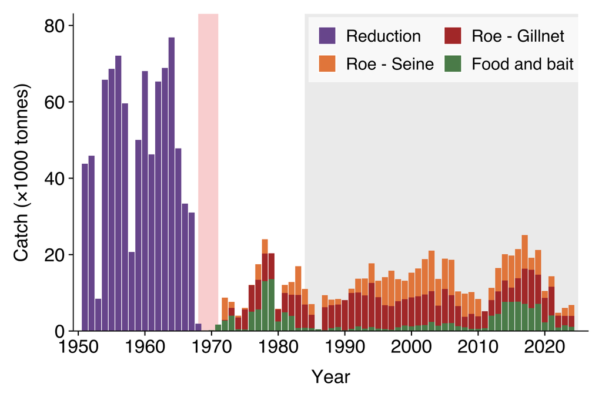

```r
shade_layer <- geom_rect(data = shade_df,
                         aes(xmin = xmin, xmax = xmax, ymin = ymin, ymax = ymax),
                         inherit.aes = FALSE, fill = "grey85", alpha = 0.45)

## ---- a  Catch by fishery type and gear -------------------------------------
fg <- catchdec %>%
  filter(area %in% OCC_AREAS, Year %in% 1951:2025) %>%
  mutate(cat = case_when(
    fishery == "Reduction"                        ~ "Reduction",
    fishery == "Roe" & gear_grp == "Gillnet"      ~ "Roe - Gillnet",
    fishery == "Roe" & gear_grp == "Seine"        ~ "Roe - Seine",
    fishery == "Roe"                              ~ "Roe - Seine",
    TRUE                                          ~ "Food and bait")) %>%
  group_by(Year, cat) %>%
  summarise(catch_kt = sum(catch_t, na.rm = TRUE)/1000, .groups = "drop") %>%
  mutate(cat = factor(cat, levels = names(fishery_cols)))

p2a <- ggplot(fg, aes(Year, catch_kt, fill = cat)) +
  shade_layer + band_closure() +
  geom_col(width = 0.9) +
  scale_fill_manual(values = fishery_cols, name = NULL) +
  scale_y_continuous(expand = expansion(mult = c(0, 0.08))) +
  labs(x = "Year", y = "Catch (×1000 tonnes)") +
  common_panel_legend(pos = c(0.99, 0.99), just = c(1, 1)) +
  guides(fill = guide_legend(nrow = 2))

## panels b, c and d of Figure 2 are drawn by Fig2bcd_manuscript_style.R
save_fig(p2a, "Fig2a_catch_by_fishery_gear")
p2a
```